# Synodos NF2 - Drug Screen Data Analysis

# Effect of Tumor Type and NF2 status on drug response.

*Model: Simpson AUC as a function of tumor type, NF2 status, drug, NF2status*drug, and organism.* This model includes all cell lines tested irrespective of organism or tumor type. The schwannoma model has an estimated 1.4-fold reduced Simpson AUC across all models as compared to the reference (meningioma). On the other hand, accounting for all other variables, NF2 status has a nonsignificant effect on Simpson AUC. Several drugs have a significant effect on Simpson AUC

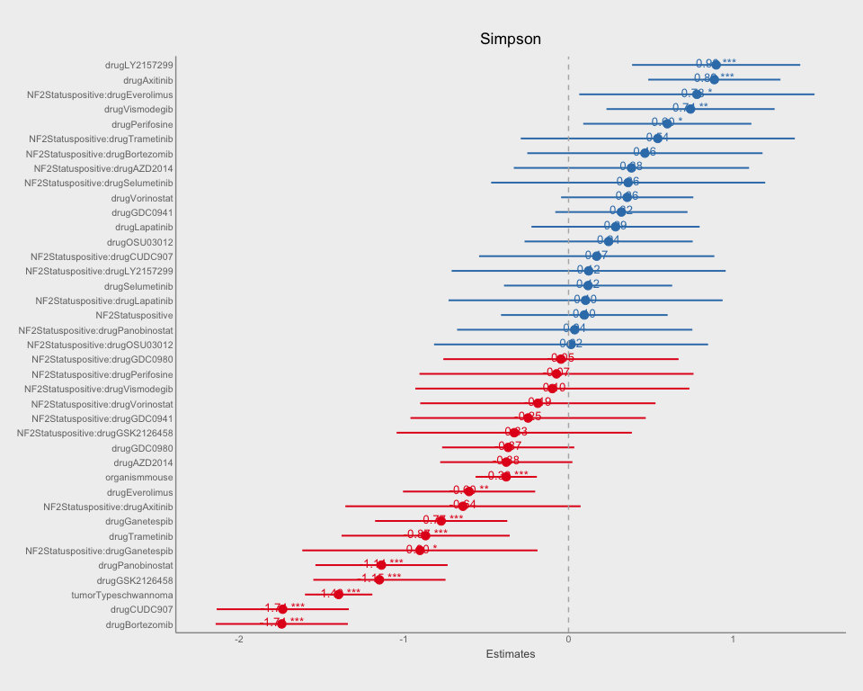

```r
m1 <- lm(Simpson ~ tumorType + NF2Status + drug + NF2Status*drug + organism, data=d)
set_theme("forest",
          axis.title.size = .85,
          axis.textsize = .85,
          legend.size = .8,
          geom.label.size = 3.5)
sjp.lm(m1)
```

The data suggest that the response (as measured by Simpson AUC) to the panel of drugs is dependent on tumor type, with the schwannoma exhibiting reduced AUC after treatment. Looking at the entire panel of small molecules, there appears to be a minimal impact of NF2 status on drug response.

```r
ggplot(data=d, aes(y=Simpson, x=tumorType, fill=NF2Status)) + geom_boxplot() + facet_grid( ~ organism)
```

[output not shown]

```r
ggplot(data=d %>% filter(log10(IC50) < 0), aes(y=log10(IC50), x=tumorType, fill=NF2Status)) + geom_boxplot() + facet_grid( ~ organism)
```

[output not shown]

In summary, these data dempnstrate that differences in drug sensitivity is more closely correlated with tumor type than NF2 genotype.